# DESeq2-MultiBatch: Batch Correction for Multi-Factorial RNA-seq Experiments

Julien Roy

2025-10-06

# Abstract

In this document, we will explore the experimental design as shown in “DESeq2-MultiBatch: Batch Correction for Multi-Factorial RNA-seq Experiments”.

The first part will provide recommendations and practical strategies for performing DESeq2 analyses with complex experimental designs. It includes specific guidance on constructing design matrices, addressing imbalanced datasets, defining appropriate contrasts, and conducting multi-factorial analyses with illustrative examples.

The second part will explain how the batch factor affects results and show in detail how to take the its effect into account. To obtain corrected counts for downstream analysis or visualizations, the DESeq2-MultiBatch will be applied and compared with limma’s RemoveBatchEffects and ComBat_Seq.

For more information about DESeq2 and the standard RNA-Seq analysis steps, refer to:

- [Analyzing RNA-seq data with DESeq2](https://bioconductor.org/packages/release/bioc/vignettes/DESeq2/inst/doc/DESeq2.html) (Love & al., 2025)
- [RNA-seq workflow: gene-level exploratory analysis and differential expression](https://bioconductor.org/packages/release/workflows/vignettes/rnaseqGene/inst/doc/rnaseqGene.html) (Love & al., 2019)

# Context and initial DESeq2 setup

## Experimental design

The simulated dataset used in this study consists of 1,000 genes across 48 samples.

The experimental design involves two batches, modeling gene expression in dioecious plants (e.g., XX/XY system) undergoing sex-specific treatments at two distinct time points: Day 0 (vegetative) and Day 1 (early flowering). Due to sex-specific treatments to alter flower sex, male and female plants were separated across batches:

Batch A: Female controls (n=6) and treated males (n=6)

Batch B: Male controls (n=6) and treated females (n=6)

The treatments were applied following Day 0 measurements but before Day 1 measurements, allowing Day 0 data to serve as a baseline for controlling batch effects.

Samples were collected across two genotypes, with three biological replicates per combination of sex, treatment, genotype, batch and time point.

Additionally, the length of photoperiod is changed in-between Day 0 and Day 1 to induce flowering. We can refer to Day 0 samples as “vegetative” and Day 1 samples as “early flowering”.

An overview of the experimental setup is seen below. Note that it does not include the genotype information for simplicity.

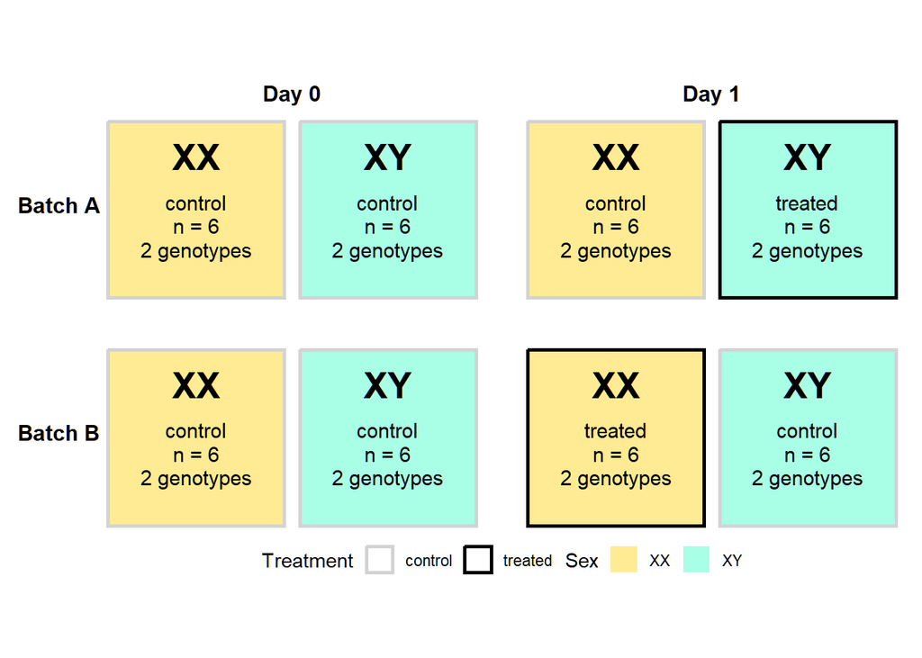

We could use the data to look at :

1. The main effects of interest in this study, which are the treatments;
2. Sex differences in gene expression for vegetative plants (“xx day 0 control” v. “xy day 0 control”);
3. Sex differences in gene expression in early-flowering plants (“xx day 1 control” v. “xy day 1 control”);
4. Change in gene expression induced by the change in photoperiod for both sexes (biologically, we expect different effects on females and males);
5. Genotype differences in gene expression (intra-species variability);
6. Differential effect of treatment across genotypes (variability of treatment response).

## Loading data files

```r
# load metadata
colData <- read.csv(file = "coldata.csv")
colData[,2:6] <- lapply(colData[,2:6], as.factor)

# load counts
counts <- read.csv(file = "counts.csv", check.names = FALSE, row.names = 1)
```

Samples are rows in the ColData, with factors as columns. In the count file, rows are genes with samples as columns.

| SampleID | Genotype | Sex | Day | Batch | Treatment |
| --- | --- | --- | --- | --- | --- |
| Sample1 | c1 | xx | 0 | a | ctrl |
| Sample2 | c1 | xx | 0 | a | ctrl |
| Sample3 | c1 | xx | 0 | a | ctrl |
| Sample4 | c2 | xx | 0 | a | ctrl |
| Sample5 | c2 | xx | 0 | a | ctrl |
| Sample6 | c2 | xx | 0 | a | ctrl |
| Sample7 | c1 | xy | 0 | a | ctrl |
| Sample8 | c1 | xy | 0 | a | ctrl |
| Sample9 | c1 | xy | 0 | a | ctrl |
| Sample10 | c2 | xy | 0 | a | ctrl |

[output cut: 38 more lines]

As you can see, the treatments are denoted “treat1” and “treat2”. It could be simply “treat”, but it would require the interaction “Treatment:Sex” to allow for independent effects of masculinisation and feminisation. Similarly, since we expect the photoperiod change to affect plants based on Sex, a Sex:Day factor is required, but colData could also have days labelled as 0, 1a (for females) and 1b (for males) to remove this interaction term.

## Exploratory analysis and visualization

To view the relationship between sample groups a simple *dds* object is first created.

The factors included in the design used for the basic DESeq2 analysis assume no batch effects and does not bother about genotypes (yet).

```r
# design
design <- ~ Day + Sex + Sex:Day + Treatment

# construct a DESeqDataSet object
dds <- DESeqDataSetFromMatrix(countData = counts,
                                  colData = colData,
                                  design = design)

dds <- DESeq(dds)

resultsNames(dds)
```

```
## [1] "Intercept"                "Day_1_vs_0"
## [3] "Sex_xy_vs_xx"             "Treatment_treat1_vs_ctrl"
## [5] "Treatment_treat2_vs_ctrl" "Day1.Sexxy"
```

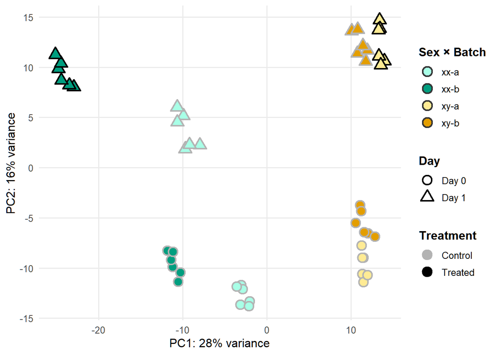

Using **intgroup = c(“Sex”, “Day”, “Batch”)**, we can see that female samples at day 0 from both batches do not cluster together. Inferring the effect of treatment simply by comparing treated and control female samples at day 1 would also include the variation from batch effects. We mix true treatment signal with batch shifts.

In our case, these can be caused by the environmental factors from the greenhouses (temperature, humidity, sunlight, etc.) or other sources of variations (personnel, irrigation, handling, etc.).

Of course, the PCA is helpful the visualize group clustering, but it does not, by itself, provide useful distances for gene expression. This is done by DESeq2.

Now, let’s look at the PCA plot using only day 0 samples, which are all control samples, without photoperiod change nor treatment, to get an overview of the batch effect.

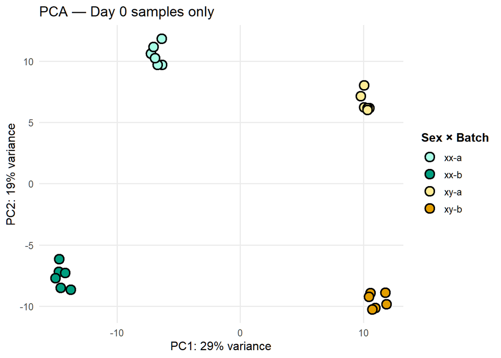

Batch effects are sizable, with samples from the same batch and sex clustering very tightly, independently of genotype (not shown here). It seems like the variation explained by the sex is on the same scale as the variation caused by batch.

The next step would be to consider including a *batch* factor in the analysis. However, this assumes that the changes in gene expression caused by the batch effect are similar for female and male plants. There are numerous reasons why dioecious plants might behave differently if the growth conditions from the greenhouse or other factors are important. For example, if this study was conducted at two separate moments in the year, batch effects would include seasonal changes.

It is possible to quantify the degree of similarity of batch effects on female and male plants by either looking at the residual distances when correcting for a single batch factor, or by plotting the log 2 fold changes caused by batch effect in female and males of all genes.

First, lets take as an example a gene that shows an interesting behaviour.

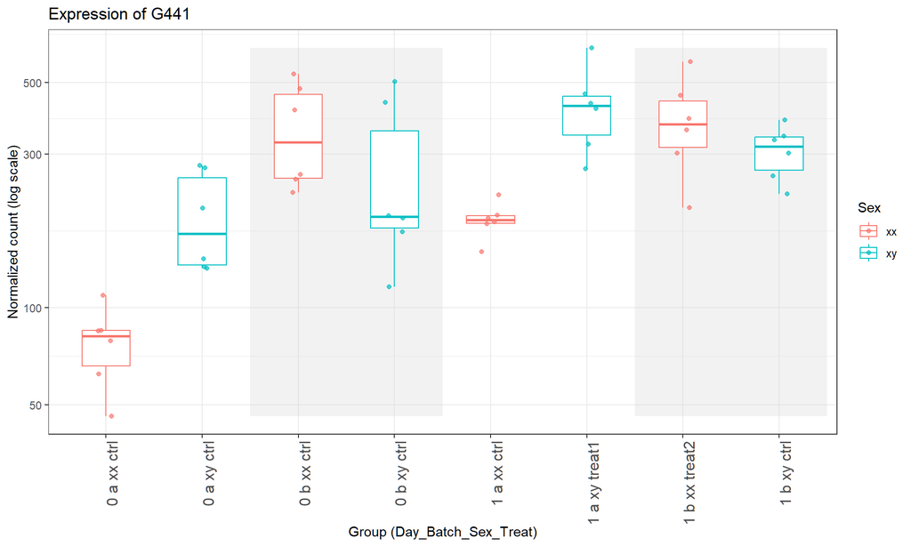

At day 0, we can see that the XX samples from batch B (3rd column) have higher counts than their counterparts from batch A (1st column), even if both of the groups are controls.

Inversely, the male samples show uniform expression values across batches at day 0 (column 2 and 4).

Lets look at the data for XX samples as seen by DESeq2 if we exclude the batch factor.

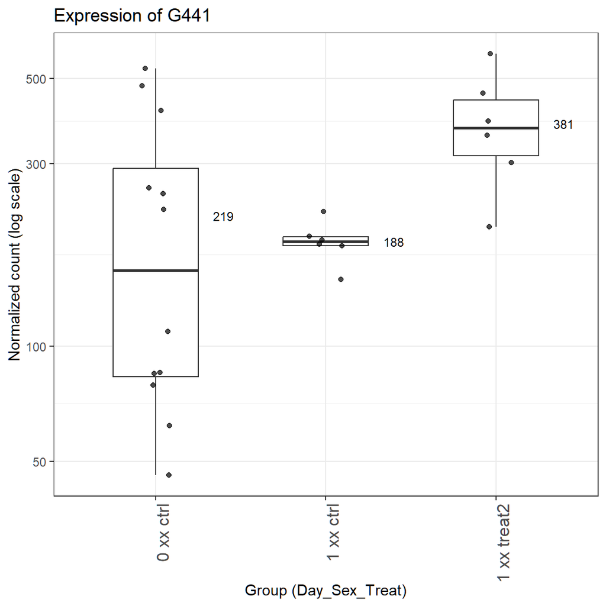

As a reminder, the design used for this *dds* object is *~ Day + Sex + Sex:Day + Treatment*

We can see that DESeq2 would use **all** XX controls at day 0 to find a baseline expression value, then would compare this value with the XX control samples at day 1 to get the effect of photoperiod change (day).

Then, XX treated compared to XX control samples at day 1 show the effect of treatment on female plants.

Here, with the average expression shown, we can already predict that the effect of the photoperiod change (control XX at day 1 v. control XX at day 0) will be minimal (LFC close to 0).

The effect of the treatment will be roughly LFC = 1 (the expression approximately doubles from 188 to 381).

```r
day_effect <- results(dds, name = "Day_1_vs_0", independentFiltering = FALSE)
day_effect[441,]
```

```
## log2 fold change (MLE): Day 1 vs 0
## Wald test p-value: Day 1 vs 0
## DataFrame with 1 row and 6 columns
##       baseMean log2FoldChange     lfcSE      stat    pvalue      padj
##      <numeric>      <numeric> <numeric> <numeric> <numeric> <numeric>
## G441   274.793      -0.222236   0.35331 -0.629011  0.529342  0.667518
```

```r
trt2_effect <- results(dds, name = "Treatment_treat2_vs_ctrl", independentFiltering = FALSE)
trt2_effect[441,]
```

```
## log2 fold change (MLE): Treatment treat2 vs ctrl
## Wald test p-value: Treatment treat2 vs ctrl
## DataFrame with 1 row and 6 columns
##       baseMean log2FoldChange     lfcSE      stat    pvalue      padj
##      <numeric>      <numeric> <numeric> <numeric> <numeric> <numeric>
## G441   274.793        1.02375  0.407072   2.51491 0.0119064 0.0351221
```

As expected, LFCs of about -0.2 and 1.0 for day and treatment, respectively. The treatment has an effect on gene expression (padj = 0.035).

Now, lets look at the data as seen by DESeq2 if we include the batch factor.

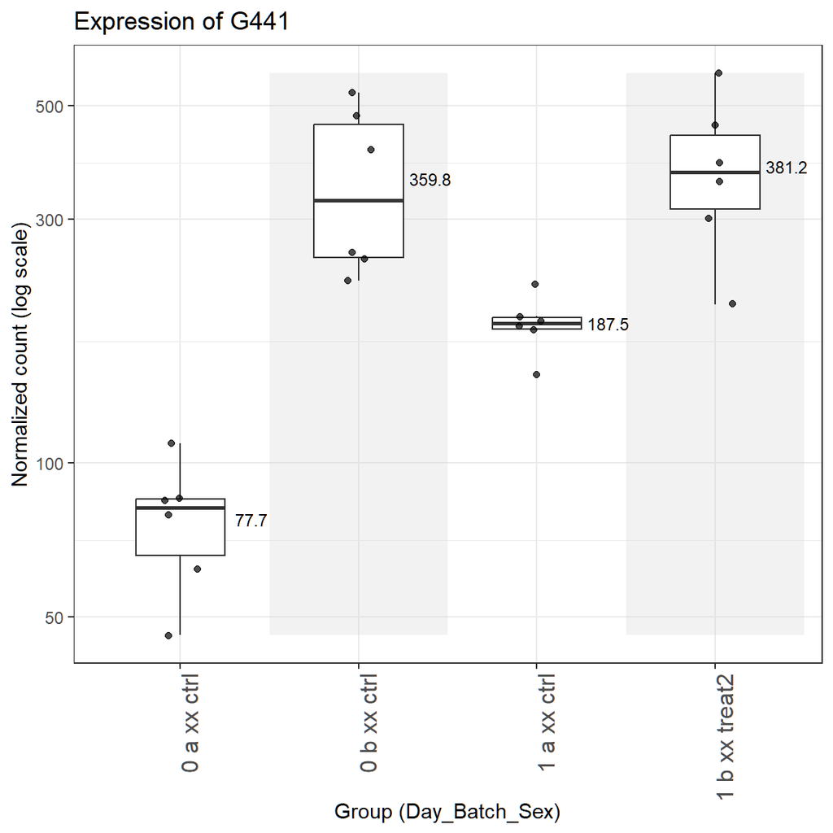

DESeq2 can extract the effect of the change in photoperiod using XX samples from batch A (controls, only received the photoperiod change).

Here, we can approximate this day effect with 188/78 for a LFC of about 1.3.

Then, if we assume that the change in photoperiod affects XX samples the same way across batches, the treatment effect would be the difference between the expected value from XX samples in batch B when the photoperiod effect is applied and the value from treated XX samples.

Let’s apply the photoperiod LFC of 1.3 to the XX samples from batch B : 360 * 2^1.3 = 886.

In other words, if XX samples from batch B were not treated, we would expect their average expression to be around 886.

The treatment effect would then be the LFC from 886/381, which is about -1.2.

This assumes that there are not interactions between the photoperiod change and the treatment.

Can we get these expected results by adding a batch factor to the design ?

```r
design <- ~ Day + Batch + Sex + Sex:Day + Treatment

dds <- DESeqDataSetFromMatrix(countData = counts,
                                  colData = colData,
                                  design = design)

dds <- DESeq(dds)
```

```r
day_effect <- results(dds, name = "Day_1_vs_0", independentFiltering = FALSE)
day_effect[441,]
```

```
## log2 fold change (MLE): Day 1 vs 0
## Wald test p-value: Day 1 vs 0
## DataFrame with 1 row and 6 columns
##       baseMean log2FoldChange     lfcSE      stat    pvalue      padj
##      <numeric>      <numeric> <numeric> <numeric> <numeric> <numeric>
## G441   274.793       0.758505  0.313468   2.41972 0.0155325 0.0543872
```

```r
trt2_effect <- results(dds, name = "Treatment_treat2_vs_ctrl", independentFiltering = FALSE)
trt2_effect[441,]
```

```
## log2 fold change (MLE): Treatment treat2 vs ctrl
## Wald test p-value: Treatment treat2 vs ctrl
## DataFrame with 1 row and 6 columns
##       baseMean log2FoldChange     lfcSE      stat    pvalue      padj
##      <numeric>      <numeric> <numeric> <numeric> <numeric> <numeric>
## G441   274.793      -0.308502  0.408033 -0.756071  0.449606  0.666583
```

Instead of 1.3 and -1.2, we get 0.75 and -0.3. This is because the model adjusts for a single batch effect and, for this gene, it is not homogeneous across sex (remember that XY samples had little batch effect for G441).

Now, let’s look at the last design that includes both a batch factor and an interaction term Sex:Batch, which allows the model to fit a separate effect of batch on XY independently from the effect of batch on XX (base level, which means the batch effect without interaction represent the effect on XX).

```r
design <- ~ Day + Batch + Sex + Sex:Batch + Sex:Day + Treatment

dds <- DESeqDataSetFromMatrix(countData = counts,
                                  colData = colData,
                                  design = design)

dds <- DESeq(dds)
```

```r
day_effect <- results(dds, name = "Day_1_vs_0", independentFiltering = FALSE)
day_effect[441,]
```

```
## log2 fold change (MLE): Day 1 vs 0
## Wald test p-value: Day 1 vs 0
## DataFrame with 1 row and 6 columns
##       baseMean log2FoldChange     lfcSE      stat      pvalue        padj
##      <numeric>      <numeric> <numeric> <numeric>   <numeric>   <numeric>
## G441   274.793        1.27074  0.294593   4.31356 1.60648e-05 0.000254997
```

```r
trt2_effect <- results(dds, name = "Treatment_treat2_vs_ctrl", independentFiltering = FALSE)
trt2_effect[441,]
```

```
## log2 fold change (MLE): Treatment treat2 vs ctrl
## Wald test p-value: Treatment treat2 vs ctrl
## DataFrame with 1 row and 6 columns
##       baseMean log2FoldChange     lfcSE      stat     pvalue      padj
##      <numeric>      <numeric> <numeric> <numeric>  <numeric> <numeric>
## G441   274.793       -1.18696   0.41132  -2.88573 0.00390508 0.0610168
```

This way, we do find the expected values of about 1.3 (photoperiod change) and -1.2 (treatment on XX) we expected.

It’s worth noting that the padj value of 0.06 is less significant than the result obtained without batch factors, even if the pvalue itself is lower. Additional factors in the design will affect the pvalues of contrasts, as the degrees of freedom depend on the amount of factors.

Part 1 will provide tips on how to call contrasts in complex designs. To correct for batch effects, including interactions with biological factors (DESeq2-MultiBatch), see Part 2 for more details.

# Part 1: Multi-factorial Analyses

## Running DESeq2 with standard design

```r
# design
design <- ~ Day + Batch + Genotype + Sex + Sex:Batch + Sex:Day + Treatment

# construct a DESeqDataSet object
dds <- DESeqDataSetFromMatrix(countData = counts,
                                  colData = colData,
                                  design = design)

# specify reference levels
dds$Genotype <- relevel(dds$Genotype, ref = "c1")
dds$Sex <- relevel(dds$Sex, ref = "xx")
dds$Batch <- relevel(dds$Batch, ref = "a")
dds$Day <- relevel(dds$Day, ref = "0")
dds$Treatment <- relevel(dds$Treatment, ref = "ctrl")

# Run DESeq
dds <- DESeq(dds)
```

## Contrast Calling

**There are multiple ways to call for a contrast of interest**

For most of these examples, *G441* will be used as an example gene, since it shows clear patterns for most factors.

Since the reference level (relevel) are sex xx, day 0, batch a, genotype c1 and ctrl, any call for contrast starts at this intercept.

### Example 1 : Effect of Photoperiod Change

#### Using resultsNames : name =, contrast =, and lis

**The first way to call for contrast is to simply specify the factor name, or a list if multiple factors are needed**

Here, let’s first extract the effect of photoperiod change on females and males.

This is straightforward, but requires using the interaction term.

```
## [1] "Intercept"                "Day_1_vs_0"
## [3] "Batch_b_vs_a"             "Genotype_c2_vs_c1"
## [5] "Sex_xy_vs_xx"             "Treatment_treat1_vs_ctrl"
## [7] "Treatment_treat2_vs_ctrl" "Batchb.Sexxy"
## [9] "Day1.Sexxy"
```

By adding Sex:Day in the design, the model has a coefficient for the effect of day for females and males. Calling for contrast name = “Day_1_vs_0” will output the change in gene expression from control female flowers at day 1 v. control female flowers at day 0. It will consider both genotypes equally, however, since we did not provide a Genotype:Day term.

```r
# coefficient name (contrast) for day change (photoperiod change) outputs effect on females
day_xx <- results(dds, name = "Day_1_vs_0", independentFiltering = FALSE)
day_xx[441,]
```

```
## log2 fold change (MLE): Day 1 vs 0
## Wald test p-value: Day 1 vs 0
## DataFrame with 1 row and 6 columns
##       baseMean log2FoldChange     lfcSE      stat      pvalue       padj
##      <numeric>      <numeric> <numeric> <numeric>   <numeric>  <numeric>
## G441   274.793        1.26935   0.29189   4.34872 1.36933e-05 0.00016498
```

If we want to answer “*what is the effect of photoperiod change on male flowers?*”, both the Day coefficient and the Sex:Day interaction coefficient must be considered.

This can be done with a list of contrasts.

```r
# coefficient name (contrast) for interaction term
int_day <- results(dds, name = "Day1.Sexxy", independentFiltering = FALSE)
int_day[441,]
```

```
## log2 fold change (MLE): Day1.Sexxy
## Wald test p-value: Day1.Sexxy
## DataFrame with 1 row and 6 columns
##       baseMean log2FoldChange     lfcSE      stat     pvalue      padj
##      <numeric>      <numeric> <numeric> <numeric>  <numeric> <numeric>
## G441   274.793       -1.07315  0.408092  -2.62968 0.00854641 0.0872082
```

```r
# coefficient name (contrast) for day change (photoperiod change) outputs effect on males
day_xy <- results(dds, contrast=list(c("Day_1_vs_0","Day1.Sexxy")), independentFiltering = FALSE)
day_xy[441,]
```

```
## log2 fold change (MLE): Day_1_vs_0+Day1.Sexxy effect
## Wald test p-value: Day_1_vs_0+Day1.Sexxy effect
## DataFrame with 1 row and 6 columns
##       baseMean log2FoldChange     lfcSE      stat    pvalue      padj
##      <numeric>      <numeric> <numeric> <numeric> <numeric> <numeric>
## G441   274.793       0.196196    0.2852  0.687924  0.491501  0.635836
```

Here are the expression levels for G441, for control plants, only including those who remained control at day 1 (half of the samples)

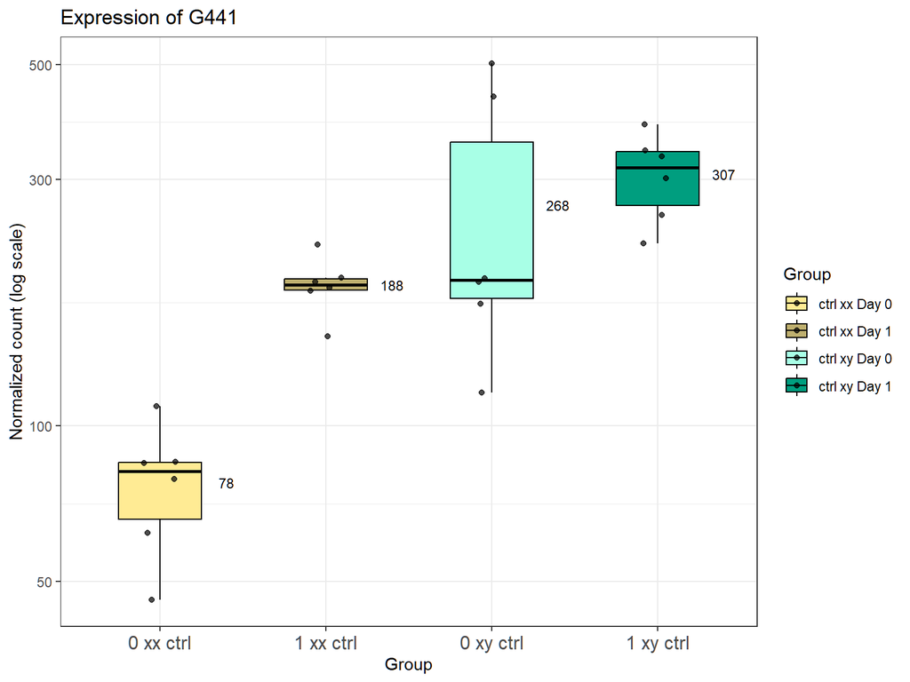

The LFC found for photoperiod effect on females (1.27) matches the expected value (78 to 188), as does the LFC for males (0.20), where the average count went from 268 to 307. The interaction term (-1.07) represents the difference between the latter and the former.

In simple terms, “Day_1_vs_0” (1.27) is applied to both males and females, while the interaction “Day1.Sexxy” (-1.07) allows to account for a different effect on males. The sum of both gives the effect of photoperiod change on males.

#### Using the Model Matrix

**The second way to call for contrasts involves using the model matrix to create groups**

Note that the comparison is done from the first group over the second : group A v. group B will show the ratio of expression of A over B.

Here, let’s compare control day 1 males to control males at day 0, hoping once again to extract the effect of photoperiod change on males.

Credit to Hugo Tavares from the BTF at Cambridge, read his explanations here : https://github.com/tavareshugo/tutorial_DESeq2_contrasts

```r
# get the model matrix
mod_mat <- model.matrix(design(dds), colData(dds))

# define the groups you wish to compare by calling columns info
xy_0 <- colMeans(mod_mat[dds$Sex == "xy" & dds$Day == "0" & dds$Treatment == "ctrl", ])
xy_1 <- colMeans(mod_mat[dds$Sex == "xy" & dds$Day == "1" & dds$Treatment == "ctrl", ])

day_xy <- results(dds, contrast = xy_1 - xy_0, independentFiltering = FALSE)
day_xy[441,]
```

```
## log2 fold change (MLE): 0,+1,+0.5,0,0,0,0,+0.5,+1
## Wald test p-value: 0,+1,+0.5,0,0,0,0,+0.5,+1
## DataFrame with 1 row and 6 columns
##       baseMean log2FoldChange     lfcSE      stat    pvalue      padj
##      <numeric>      <numeric> <numeric> <numeric> <numeric> <numeric>
## G441   274.793        0.43281  0.247179     1.751 0.0799461  0.138555
```

Weirdly, it doesn’t provide the same value as in the first example (0.43 instead of 0.20).

This is because this method uses all factors affecting the samples from the group. As the batch was not specified, it uses all male samples at day 0, since they are all control.

This can be seen in the output :

“log2 fold change (MLE): 0,+1,+0.5,0,0,0,0,+0.5,+1”

The third and before-last columns from the model matrix refer the the Batch and Batch:Sex factors. They are halved because half the samples belong to the batch B. If we had done the same thing, but for female samples, the third term would also be 0.5, but the before-last would be 0 since the interaction term does not apply to the reference levels (here, xx).

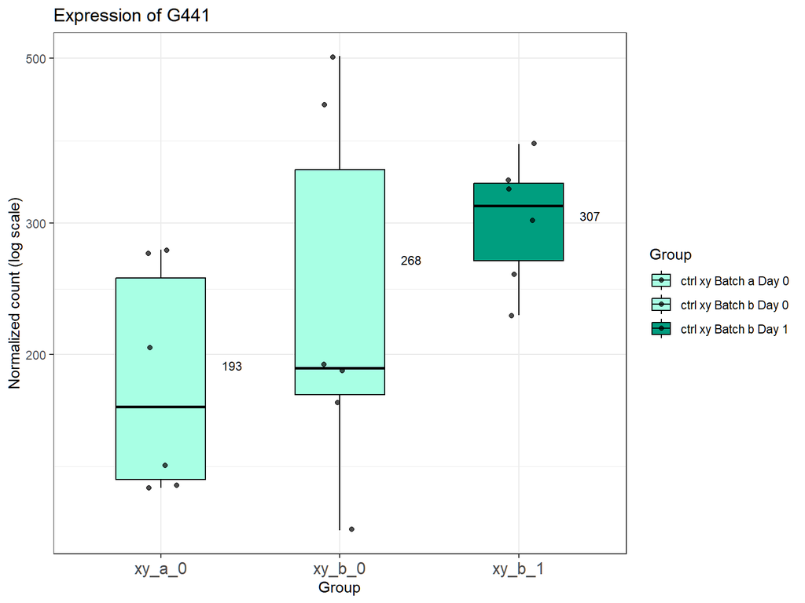

This shows what the model uses : both batches at day 0, and the controls from batch b at day 1.

Like in the first example, let’s extract the Batch effect for males using the Batch and the Batch:Sex factor

```r
batch_xy <- results(dds, contrast=list(c("Batch_b_vs_a","Batchb.Sexxy")), independentFiltering = FALSE)
batch_xy[441,]
```

```
## log2 fold change (MLE): Batch_b_vs_a+Batchb.Sexxy effect
## Wald test p-value: Batch_b_vs_a+Batchb.Sexxy effect
## DataFrame with 1 row and 6 columns
##       baseMean log2FoldChange     lfcSE      stat    pvalue      padj
##      <numeric>      <numeric> <numeric> <numeric> <numeric> <numeric>
## G441   274.793       0.473228  0.286363   1.65255 0.0984225  0.213036
```

The LFC (0.47) is consistent with the count values (193 to 268).

Half of this result (0.235) is added to the “true” photoperiod change : 0.20 + 0.235 is around 0.43, as seen in the first incorrect result.

This can be fixed by being specific when defining groups

```r
# define control males at day 1 and control (all) males at day 0
xy_1 <- colMeans(mod_mat[dds$Sex == "xy" & dds$Day == "1" & dds$Treatment == "ctrl", ])
xy_0 <- colMeans(mod_mat[dds$Sex == "xy" & dds$Day == "0" & dds$Batch == "b", ])

day_xy <- results(dds, contrast = xy_1 - xy_0, independentFiltering = FALSE)
day_xy[441,]
```

```
## log2 fold change (MLE): 0,+1,0,0,0,0,0,0,+1
## Wald test p-value: 0,+1,0,0,0,0,0,0,+1
## DataFrame with 1 row and 6 columns
##       baseMean log2FoldChange     lfcSE      stat    pvalue      padj
##      <numeric>      <numeric> <numeric> <numeric> <numeric> <numeric>
## G441   274.793       0.196196    0.2852  0.687924  0.491501  0.635836
```

The Batch == “b” at day 0 forces the model to use only the samples from batch B at day 0. It could have been done in many ways, such as Batch == “b” instead of Treatment == “ctrl” at day 1, but the calculation will be the same.

**This method does not provide accurate results in the case of imbalanced datasets**

Both batches have 6 samples. Let’s change this by removing Sample35 from counts and colData, re-runnig DESeq2, and then try to find the photoperiod change effect for males:

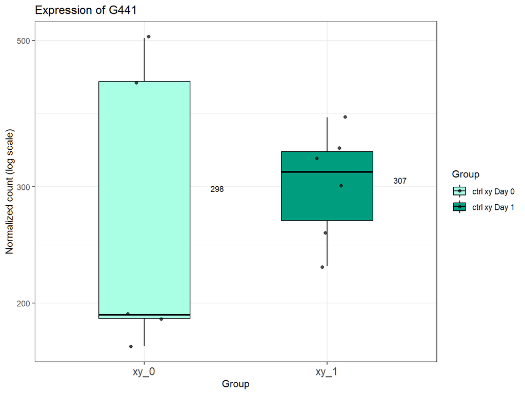

Now, the average counts are 298 (from the removal of Sample35) and 307 (same as before). From this, we would expect a LFC of about 0.04.

```r
day_xy <- results(dds_imba, contrast=list(c("Day_1_vs_0","Day1.Sexxy")), independentFiltering = FALSE)
day_xy[441,]
```

```
## log2 fold change (MLE): Day_1_vs_0+Day1.Sexxy effect
## Wald test p-value: Day_1_vs_0+Day1.Sexxy effect
## DataFrame with 1 row and 6 columns
##       baseMean log2FoldChange     lfcSE      stat    pvalue      padj
##      <numeric>      <numeric> <numeric> <numeric> <numeric> <numeric>
## G441   277.846       0.040897  0.286868  0.142564  0.886635  0.934126
```

We get the expected result using the contrast names.

Let’s try with the model matrix method.

```r
xy_0 <- colMeans(mod_mat[dds_imba$Sex == "xy" & dds_imba$Day == "0" & dds_imba$Batch == "b", ])
xy_1 <- colMeans(mod_mat[dds_imba$Sex == "xy" & dds_imba$Day == "1" & dds_imba$Batch == "b", ])

day_xy <- results(dds_imba, contrast = xy_1 - xy_0, independentFiltering = FALSE)
day_xy[441,]
```

```
## log2 fold change (MLE): 0,+1,0,+0.1,-0.166666666666667,0,+0.166666666666667,-0.166666666666667,+0.833333333333333
## Wald test p-value: 0,+1,0,+0.1,-0.166666666666667,0,+0.166666666666667,-0.166666666666667,+0.833333333333333
## DataFrame with 1 row and 6 columns
##       baseMean log2FoldChange     lfcSE      stat    pvalue      padj
##      <numeric>      <numeric> <numeric> <numeric> <numeric> <numeric>
## G441   277.846      0.0922042  0.267827  0.344268  0.730645   0.82189
```

We get a slightly different result (0.09) because the model uses ratios from the amount of samples.

This can be seen in the printed output of the values given to each column of the model matrix :

0,+1,0,+0.1,-0.166666666666667,0,+0.166666666666667,-0.166666666666667,+0.833333333333333

These values in the “contrast vector” represent the weights of each factors of the model matrix taken into account for this specific contrast

The imbalance of replicates for cultivars in some groups (when n=5, genotypes are 2 + 3) skews the group contrast (decimals values in the contrast vector).

This method is still usable, as it is quite easy to implement, but it needs to be well understood.

#### Using a Contrast Vector

**The third way to call for contrast, using a contrast vector, is more precise**

```r
# define weights for each factor
contrast_vector_day <- c(0,1,0,0,0,0,0,0,1) # this is the same vector, without decimal values from imbalance
day_xy_imba <- results(dds_imba, contrast = contrast_vector_day, independentFiltering = FALSE)
day_xy_imba[441,]
```

```
## log2 fold change (MLE): 0,+1,0,0,0,0,0,0,+1
## Wald test p-value: 0,+1,0,0,0,0,0,0,+1
## DataFrame with 1 row and 6 columns
##       baseMean log2FoldChange     lfcSE      stat    pvalue      padj
##      <numeric>      <numeric> <numeric> <numeric> <numeric> <numeric>
## G441   277.846       0.040897  0.286868  0.142564  0.886635  0.934126
```

This result shows the expected LFC value from the effect of photoperiod change on males on the imbalanced dataset, as found previously using contrast names: “list(c(”Day_1_vs_0”,“Day1.Sexxy”)).

## Using Contrast Vectors for our Experimental Design

### Effect of Treatments

First, let’s plot the female and male expressions separately, for all groups, to get a better intuition of the comparisons we are trying to extract.

The experimental design requires to use the change in expression from the photoperiod change from control samples of each sex across days, then substracting this effect to the change in expression of the treated samples. We assume no interaction between the photoperiod change and the treatment.

We can’t simply compare the treated samples at day 1 with the controls at day 1, which would be the standard way of obtaining the effect of treatment, since this would include the batch variation

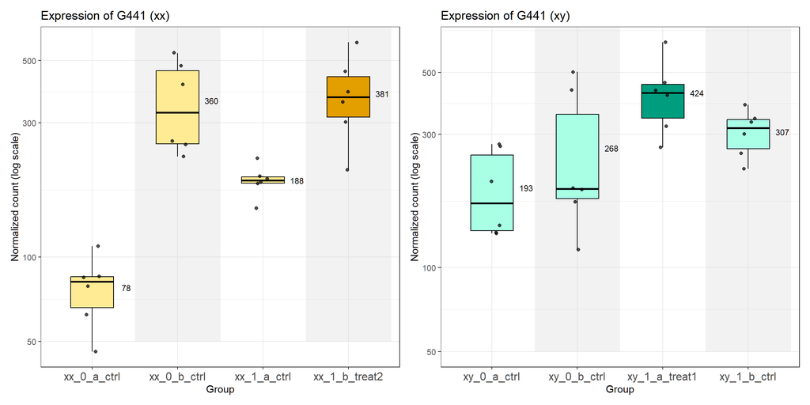

For this G441 gene, control female samples that underwent a photoperiod change between day 0 and 1 had their expression level go from 78 to 188, so we expect the effect of Day to be 1.27, as found previously. Since treated samples from batch B had this day change effect, we would expect the counts to go from 360 to about 868. However, they show nearly unchanged expression (360 to 381), with a LFC of 0.08. The effect of the treatment should then be 0.08 - 1.27, which is around -1.19.

For males, control samples had their expression level go from 268 to 307 (batch B), so we expect the effect of Day in males to be 0.20, as found previously. For treated samples, we would expect the counts to go from 193 to about 221. However, the average expression is around 424, for a LFC of 1.14. The effect of the treatment should then be 1.14 - 0.20, which is around 0.94.

Using contrast vectors, we can easily extract these contrasts. Note that treated male samples are labelled as “treat1” in colData, and females are “treat2”.

```r
cv_treat_xx <- c(0,0,0,0,0,0,1,0,0)
treat_xx <- results(dds, contrast = cv_treat_xx, independentFiltering = FALSE)
treat_xx[441,]
```

```
## log2 fold change (MLE): 0,0,0,0,0,0,+1,0,0
## Wald test p-value: 0,0,0,0,0,0,+1,0,0
## DataFrame with 1 row and 6 columns
##       baseMean log2FoldChange     lfcSE      stat     pvalue      padj
##      <numeric>      <numeric> <numeric> <numeric>  <numeric> <numeric>
## G441   274.793        -1.1824  0.407453  -2.90193 0.00370874 0.0475479
```

```r
cv_treat_xy <- c(0,0,0,0,0,1,0,0,0)
treat_xy <- results(dds, contrast = cv_treat_xy, independentFiltering = FALSE)
treat_xy[441,]
```

```
## log2 fold change (MLE): 0,0,0,0,0,+1,0,0,0
## Wald test p-value: 0,0,0,0,0,+1,0,0,0
## DataFrame with 1 row and 6 columns
##       baseMean log2FoldChange     lfcSE      stat    pvalue      padj
##      <numeric>      <numeric> <numeric> <numeric> <numeric> <numeric>
## G441   274.793       0.940357  0.403587      2.33 0.0198062  0.117197
```

## Complex Design

**This part is under construction and will be updated shortly**

1. Sex difference at day 0;
2. Photoperiod change in both sexes;
3. Batch effect in both sexes

**This part is under construction and will be updated shortly**

Now that the various designs that allow us to extract the treatment effects accurately, both for XX and XY samples, are understood, we might want to correct for batch effects.

This is not needed for contrasts calling with DESeq2. Please refer to the main text “DESeq2-MultiBatch: Batch Correction for Multi-Factorial RNA-seq Experiments” for details.

However, for boxplots, bar graph, heatmaps, principal components analysis or other downstream analysis, batch effect correction can be of interest.

Since we need to correct for batch effects in XX and XY samples independently, a standard pipeline using known tools (limma’s removeBatchEffects or comBat-seq) might not provide the expected results.

# Part 2: Batch effect correction

## Running DESeq2 with standard design

Two designs are proposed : one with a *Batch* factor, and another one with both *Batch* and the interaction term *Sex:Batch*

```r
# design
design_single <- ~ Day + Batch + Genotype + Sex + Sex:Day + Treatment

# construct a DESeqDataSet object
dds_single <- DESeqDataSetFromMatrix(countData = counts,
                                  colData = colData,
                                  design = design_single)

# run DESeq
dds_single <- DESeq(dds_single)
```

```r
# design
design <- ~ Day + Batch + Genotype + Sex + Sex:Batch + Sex:Day + Treatment

# construct a DESeqDataSet object
dds <- DESeqDataSetFromMatrix(countData = counts,
                                  colData = colData,
                                  design = design)

# run DESeq
dds <- DESeq(dds)
```

Note that its inclusion will not change the calculation of effects of treatment or other factors, as long as we do not include interaction terms between genotypes and these other factors.

The interaction term *Sex:Batch* is the main concept discussed in the article, and is necessary to apply the double batch correction to the data for visualization and downstream analyses.

## Apply the correction

First, run the function MultiBatch

```r
MultiBatch <- function(
    dds,
    batch_factor,
    interact_factor = NULL,
    mode = c("center", "reference"),
    use_normalized = TRUE,
    round_out = TRUE,
    independentFiltering = FALSE,
    verbose = TRUE
) {
  stopifnot(is(dds, "DESeqDataSet"))
  mode <- match.arg(mode)

  rnames <- DESeq2::resultsNames(dds)
  cd <- as.data.frame(SummarizedExperiment::colData(dds))
  if (!batch_factor %in% names(cd))
    stop("batch_factor '", batch_factor, "' not found in colData(dds).")
  if (!is.null(interact_factor) && !interact_factor %in% names(cd))
    stop("interact_factor '", interact_factor, "' not found in colData(dds).")

  nc <- DESeq2::counts(dds, normalized = use_normalized)
  nc <- as.matrix(nc)
  G <- nrow(nc)

  bf <- as.factor(cd[[batch_factor]])
  b_levels <- levels(bf)
  if (is.null(b_levels) || length(b_levels) < 2)
    stop("Batch factor must have at least 2 levels.")
  b_ref <- b_levels[1]

  if (is.null(interact_factor)) {
    if (verbose) message("No interact_factor provided; adjusting Batch main effect only.")
    int_levels <- "(no-int)"
    i_ref <- "(no-int)"
    int_vec <- rep("(no-int)", nrow(cd))
  } else {
    intf <- as.factor(cd[[interact_factor]])
    int_levels <- levels(intf)
    i_ref <- int_levels[1]
    int_vec <- as.character(intf)
  }

  safe_lfc <- function(v) {
    v[is.na(v)] <- 0
    as.numeric(v)
  }

  get_lfc_by_name <- function(coef_name) {
    if (!(coef_name %in% rnames)) {
      if (verbose) message("  (missing coef) ", coef_name)
      return(rep(0, G))
    }
    res <- DESeq2::results(dds, name = coef_name, independentFiltering = independentFiltering)
    safe_lfc(res$log2FoldChange)
  }

  batch_coef_name <- function(batch_level) {
    paste0(batch_factor, "_", batch_level, "_vs_", b_ref)
  }

  interaction_coef_name <- function(b_lev, i_lev) {
    if (is.null(interact_factor) || b_lev == b_ref || i_lev == i_ref) return(NA_character_)
    candidates <- c(
      paste0(batch_factor, b_lev, ".", interact_factor, i_lev),
      paste0(interact_factor, i_lev, ".", batch_factor, b_lev)
    )
    hit <- candidates[candidates %in% rnames]
    if (length(hit) == 0) NA_character_ else hit[1]
  }

  if (verbose) message("Collecting main Batch coefficients relative to '", b_ref, "'...")
  main_batch_LFC <- vector("list", length(b_levels))
  names(main_batch_LFC) <- b_levels
  main_batch_LFC[[b_ref]] <- rep(0, G)
  for (bl in b_levels[b_levels != b_ref]) {
    nm <- batch_coef_name(bl)
    if (verbose) message("  ", nm)
    main_batch_LFC[[bl]] <- get_lfc_by_name(nm)
  }

  delta_by_intlevel <- vector("list", length(int_levels))
  names(delta_by_intlevel) <- int_levels

  if (is.null(interact_factor)) {
    M <- do.call(cbind, main_batch_LFC)
    colnames(M) <- b_levels
    delta_by_intlevel[[1]] <- M
  } else {
    if (verbose) message("Collecting Batch: ", interact_factor, " interaction coefficients...")
    for (il in int_levels) {
      # start from main batch effects
      M <- do.call(cbind, main_batch_LFC)
      colnames(M) <- b_levels

      if (il != i_ref) {
        for (bl in b_levels[b_levels != b_ref]) {
          nm_int <- interaction_coef_name(bl, il)
          if (!is.na(nm_int)) {
            if (verbose) message("  + ", nm_int)
            M[, bl] <- M[, bl] + get_lfc_by_name(nm_int)
          } else {
            if (verbose) message("  (no explicit coef for ", bl, "×", il, ")")
          }
        }
      }
      delta_by_intlevel[[il]] <- M
    }
  }

  if (verbose) message("Computing per-gene scaling factors (mode = '", mode, "').")
  scale_by_intlevel <- lapply(delta_by_intlevel, function(M) {
    if (mode == "center") {
      row_means <- rowMeans(M, na.rm = TRUE)
      sweep_M <- sweep(M, 1, row_means, FUN = "-")
      2^(-sweep_M)
    } else {
      2^(-M)
    }
  })

  if (verbose) message("Applying scaling factors to columns of the count matrix...")
  out <- nc
  sample_batches <- as.character(bf)
  for (j in seq_len(ncol(nc))) {
    bl <- sample_batches[j]
    il <- int_vec[j]
    if (is.null(interact_factor)) il <- "(no-int)"

    S <- scale_by_intlevel[[il]][, bl]
    out[, j] <- nc[, j] * S
  }

  if (round_out) {
    out <- round(out)
    storage.mode(out) <- "integer"
  }

  if (verbose) {
    message("Done.")
    message("Reference levels inferred from colData(): ",
            batch_factor, "='", b_ref, "'",
            if (!is.null(interact_factor)) paste0(", ", interact_factor, "='", i_ref, "'") else "")
  }

  list(
    adjusted_counts = out,
    scaling_tables = scale_by_intlevel,
    delta_tables   = delta_by_intlevel,
    batch_levels   = b_levels,
    interact_levels = int_levels,
    reference = list(batch = b_ref, interact = i_ref),
    mode = mode,
    used_results_names = rnames
  )
}
```

### Single Batch Factor

```r
adj_s <- MultiBatch(
  dds_single,
  batch_factor    = "Batch",
  interact_factor = NULL,
  mode = "center",
  use_normalized = TRUE,
  round_out = TRUE,
  verbose = TRUE)

scaled_counts_single <- adj_s$adjusted_counts
```

```r
adj_d <- MultiBatch(
  dds,
  batch_factor    = "Batch",
  interact_factor = "Sex",
  mode = "center",
  use_normalized = TRUE,
  round_out = TRUE,
  verbose = TRUE)
```

```
##   Batch_b_vs_a
```

```
##   + Batchb.Sexxy
```

```
## Computing per-gene scaling factors (mode = 'center').
```

```
## Applying scaling factors to columns of the count matrix...
```

```
## Done.
```

[output not shown]

```r
scaled_counts_double <- adj_d$adjusted_counts
```

Since the base level is XX, “Batch_b_vs_a” is the effect on females, while the batch effect on male is the combination of both the batch (“Batch_b_vs_a”) and interaction (“Batchb.Sexxy”) term. This will be shown visually later.

The LFC values are stored for each gene. This correction aims for the midpoint on the log-scale.

We use the normalized counts from DESeq2 (with the simulated datasets, the size factors are quite close to 1 for all samples, meaning the results are similar either way).

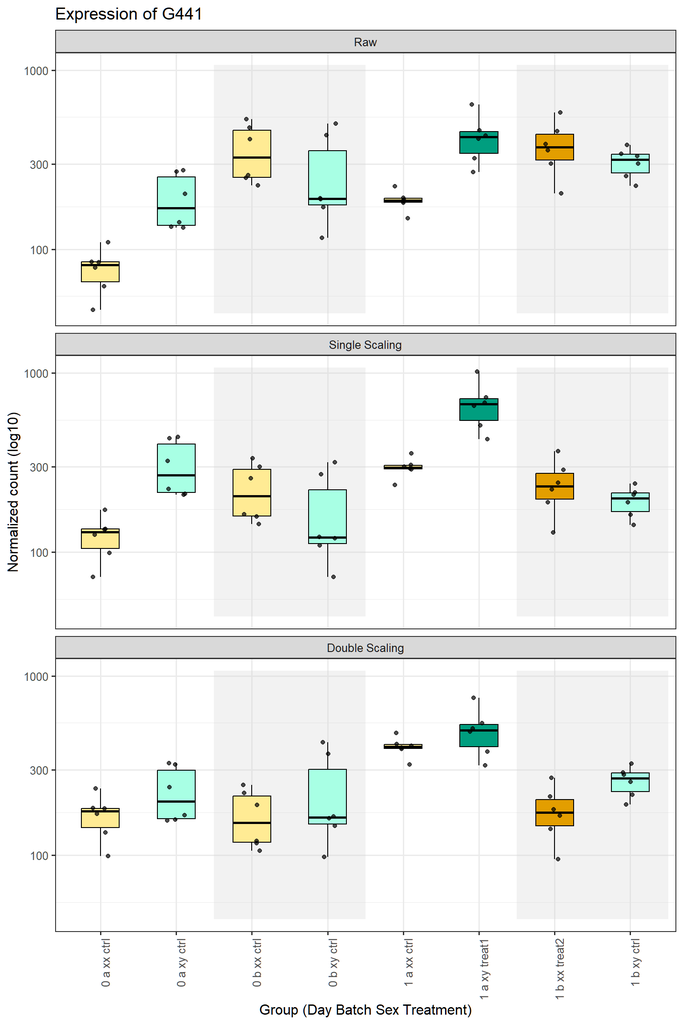

Focusing on the data at day 0, we see that the single batch correction adjusts the counts from both batches so their averages are somewhat equivalent. While this reduces the variation attributed to the batch factor, it can induce unwanted adjustments to samples of a given sex if there is a sizable interaction with the batch effect.

The double correction provides alignments of same-sex samples across batches. This allows the visualizations to be simplified by removing the batch factor in the grouping.

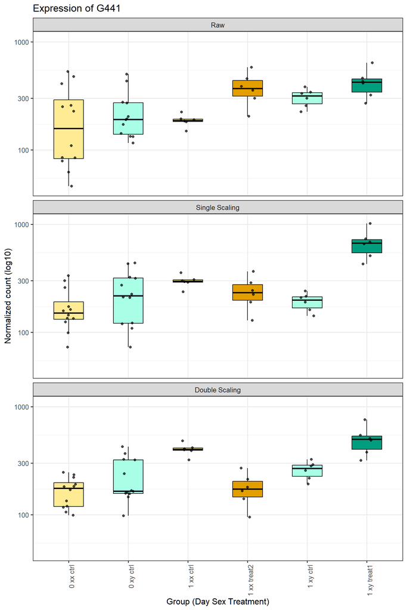

## Limma and comBat-seq

These next steps create other DDS objects to compare with the single batch correction using a similar method (as seen in “DESeq2-MultiBatch: Batch Adjustment for Multi-Factorial RNA-seq Experiments”) and popular tools for RNA-seq pipelines.

First, a new colData is created, which uses a different notation for batches : samples from batch A are still “A”, and females from batch B are still “B”, but males from batch B are now “C”.

```r
colData_abc <- colData
colData_abc$Batch <- as.character(colData_abc$Batch)
colData_abc$Batch <- ifelse(colData_abc$Sex == "xy" & colData_abc$Batch == "b", "c", colData_abc$Batch)
colData_abc$Batch <- as.factor(colData_abc$Batch)
```

The intuitive A/B batch notation, which better reflects the experimental setup, only allows for a single batch correction that does not include an interaction term, to my knowledge.

Using A, B and C provides factors to compare B and A, then C and A independently. This colData format allows ComBat-seq and limma to provide a double batch correction by mimicking the interaction between Batch and Sex. However, it runs into issues later.

```r
design_nobatch <- ~ Day + Genotype + Sex + Sex:Day + Treatment
design_nosex <- ~ Day + Genotype + Treatment
design_matrix_nobatch <- model.matrix(design_nobatch, data = colData_abc)
design_matrix_nosex <- model.matrix(design_nosex, data = colData_abc)

dds_new <- DESeqDataSetFromMatrix(countData = round(normalized_counts_df),
                                  colData = colData,
                                  design = design_nobatch)

dds_single_nobatch <- DESeqDataSetFromMatrix(countData = scaled_counts_single,
                                  colData = colData,
                                  design = design_nobatch)

dds_double_nobatch <- DESeqDataSetFromMatrix(countData = scaled_counts_double,
                                  colData = colData,
                                  design = design_nobatch)

vsd_new <- vst(dds_new, blind = FALSE)
vsd_scaled_single <- vst(dds_single_nobatch, blind = FALSE)
vsd_scaled_double <- vst(dds_double_nobatch, blind = FALSE)

vsd_matrix <- assay(vsd_new)

# use limma
vsd_limma_matrix <- removeBatchEffect(vsd_matrix, batch = colData$Batch, design = design_matrix_nobatch)
vsd_limma_matrix_abc <- removeBatchEffect(vsd_matrix, batch = colData_abc$Batch, design = design_matrix_nobatch)

vsd_limma <- vsd_new
vsd_limma_abc <- vsd_new
assay(vsd_limma) <- vsd_limma_matrix
assay(vsd_limma_abc) <- vsd_limma_matrix_abc

# use combat
combat_data <- ComBat_seq(counts = as.matrix(round(normalized_counts_df)), batch = colData$Batch, covar_mod = design_matrix_nobatch, full_mod = TRUE)
```

```
## Found 2 batches
## Using null model in ComBat-seq.
## Adjusting for 6 covariate(s) or covariate level(s)
## Estimating dispersions
## Fitting the GLM model
## Shrinkage off - using GLM estimates for parameters
## Adjusting the data
```

```r
combat_data_abc <- ComBat_seq(counts = as.matrix(round(normalized_counts_df)), batch = colData_abc$Batch, covar_mod = design_matrix_nobatch, full_mod = TRUE)
```

```
## Found 3 batches
## Using null model in ComBat-seq.
## Adjusting for 6 covariate(s) or covariate level(s)
## Estimating dispersions
## Fitting the GLM model
## Shrinkage off - using GLM estimates for parameters
## Adjusting the data
```

```r
dds_combat <- DESeqDataSetFromMatrix(countData = combat_data,
                                  colData = colData,
                                  design = design_nobatch)

dds_combat_abc <- DESeqDataSetFromMatrix(countData = combat_data_abc,
                                  colData = colData_abc,
                                  design = design_nobatch)

vsd_combat_single <- vst(dds_combat, blind = FALSE)
vsd_combat_double <- vst(dds_combat_abc, blind = FALSE)
```

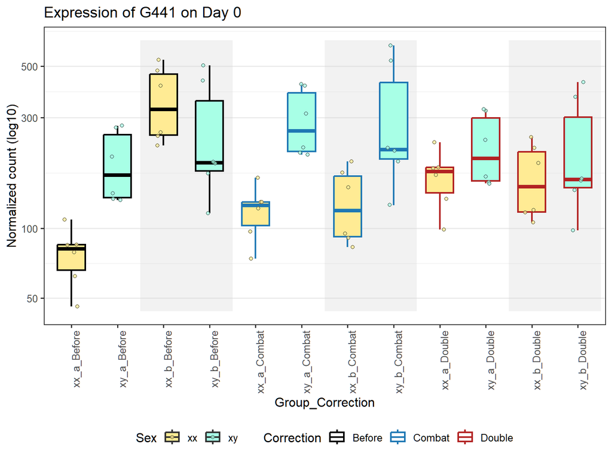

We can see the issue with the ComBat-Seq adjustment. While the average of samples at day 0 are adjusted across batches for both sexes, the offset between sexes is not accurate. ComBat-Seq tries to keep the “Sex” factor intact : since this effect is calculated from the reference batch (a), the distance between female and male samples at day 0 from batch A is kept, and samples from batch b are drawn towards batch a’s expression levels. This will affect the coefficients for factors of the design.

On the other hand, MultiBatch allows to center, without reference batch.

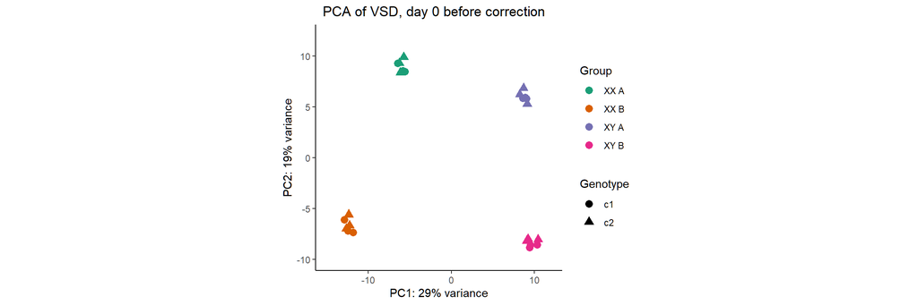

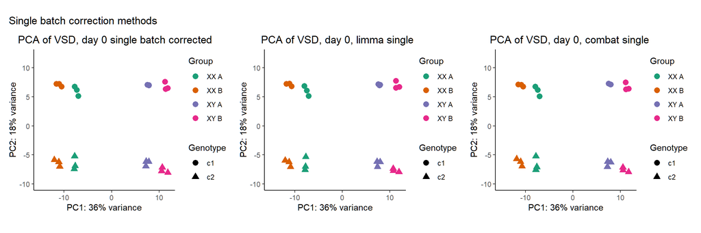

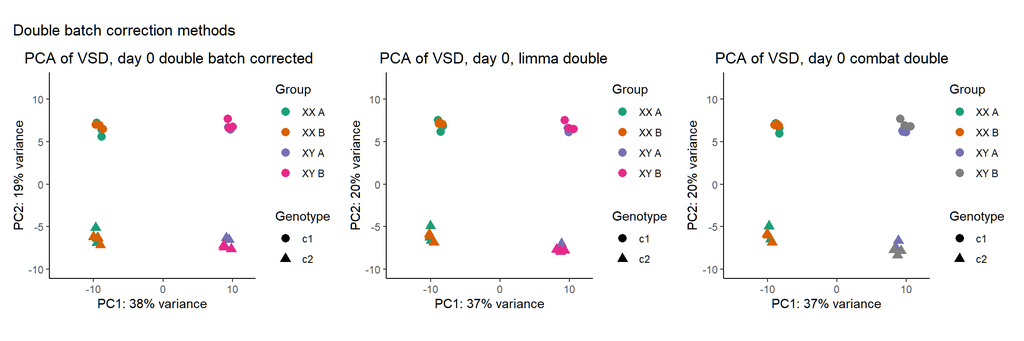

```r
# new contrast as test
batch_xx <- results(dds, name = "Batch_b_vs_a", independentFiltering = FALSE)
batch_xx <- as.data.frame(batch_xx)
batch_xy <- results(dds, contrast=list(c("Batch_b_vs_a","Batchb.Sexxy")), independentFiltering = FALSE)
batch_xy <- as.data.frame(batch_xy)

batch_int <- results(dds, name = "Batchb.Sexxy", independentFiltering = FALSE)
batch_int <- as.data.frame(batch_int)

int_genes <- rownames(batch_int)[order(abs(batch_int$log2FoldChange), decreasing = TRUE)][1:3]
int_genes #effect specific to male (batch:sex)
```

```
## [1] "G818" "G573" "G164"
```

```r
# select top genes from 3 conditions
xx_genes <- rownames(batch_xx)[order(abs(batch_xx$log2FoldChange), decreasing = TRUE)][1:4]
xy_genes <- rownames(batch_xy)[order(abs(batch_xy$log2FoldChange), decreasing = TRUE)][1:3]

#main_genes #XX
xx_genes #XX
```

```
## [1] "G844" "G442" "G250" "G441"
```

```r
xy_genes #XY
```

```
## [1] "G932" "G817" "G442"
```

```r
gene_list <- union(union(xx_genes, xy_genes), int_genes)
gene_list <- gene_list[-1]
gene_list <- c(gene_list, "G78")
gene_list
```

```
## [1] "G442" "G250" "G441" "G932" "G817" "G818" "G573" "G164" "G78"
```

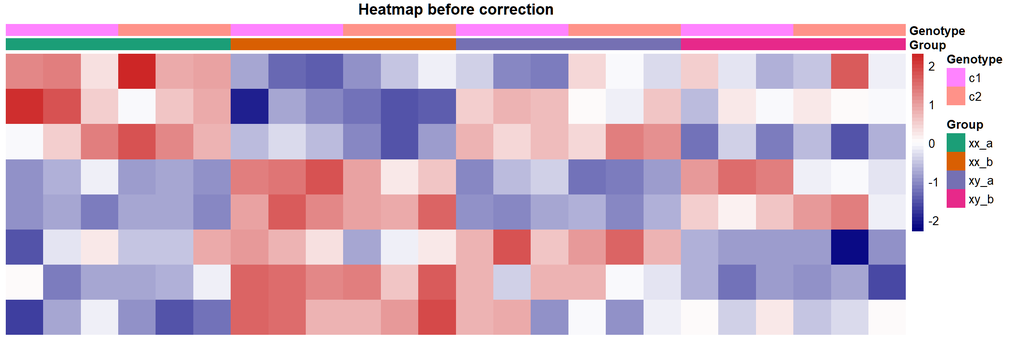

```r
gene_list_ordered <- c("G818", "G844", "G932", "G442", "G250", "G817", "G573", "G78")

# Define the function with gene ordering (gene_list is always provided)
create_heatmap <- function(vsd, title) {
  # Extract the assay data and use only the genes in the provided list, in the specified order.
  vsd_data <- assay(vsd)
  vsd_data <- vsd_data[rownames(vsd_data) %in% gene_list_ordered, , drop = FALSE]
  vsd_data <- vsd_data[match(gene_list_ordered, rownames(vsd_data)), , drop = FALSE]

  # Access the colData from the vsd object and add a grouping column.
  colData_vsd <- as.data.frame(colData(vsd))
  colData_vsd$Group <- paste(colData_vsd$Sex, colData_vsd$Batch, sep = "_")
  colData(vsd) <- DataFrame(colData_vsd)

  # Create an annotation data frame for the heatmap.
  annotation_col <- as.data.frame(colData(vsd)[, c("Group", "Genotype")])
  rownames(annotation_col) <- colnames(vsd_data)

  # Define custom order for the Group factor (for column ordering).
  custom_order <- c("xx_a", "xx_b", "xy_a", "xy_b")

  # Order the samples by the custom Group factor levels.
  ordered_sample_indices <- order(factor(annotation_col$Group, levels = custom_order))
  vsd_data_ordered <- vsd_data[, ordered_sample_indices]
  annotation_col_ordered <- annotation_col[ordered_sample_indices, ]

  # Load RColorBrewer and define color palettes for annotations.
  library(RColorBrewer)
  num_treatments <- 4
  group_colors <- brewer.pal(n = num_treatments, name = "Dark2")
  cultivar_colors <- brewer.pal(n = 8, name = "Dark2")[5:6]

  annotation_colors <- list(
    Group = setNames(group_colors, unique(annotation_col_ordered$Group)),
    Cultivar = setNames(cultivar_colors, unique(annotation_col_ordered$Cultivar))
  )

  # Optionally, assign custom labels for the Group factor.
  custom_labels <- c("XX A", "XX B", "XY A", "XY B")
  annotation_col$Group <- factor(annotation_col$Group,
                                 levels = custom_order,
                                 labels = custom_labels)

  # Generate the heatmap with row clustering disabled.
  heatmap <- pheatmap(vsd_data_ordered,
                      cluster_rows = FALSE,
                      treeheight_row  = 0,
                      cluster_cols = FALSE,
                      show_rownames = FALSE,
                      show_colnames = FALSE,
                      annotation_col = annotation_col_ordered,
                      annotation_colors = annotation_colors,
                      scale = "row",
                      main = title,
                      fontsize_row = 10,
                      fontsize_col = 8,
                      color = colorRampPalette(c("navy", "white", "firebrick3"))(50),
                      border_color = NA)

  return(heatmap)
}

# Use the function
# uncorrected
heatmap <- create_heatmap(vsd_filtered, "Heatmap before correction")
```

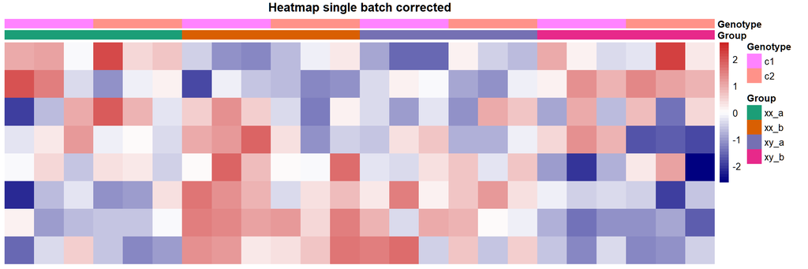

```r
# alt version

# single corrected
heatmap_single <- create_heatmap(vsd_single_filtered, "Heatmap single batch corrected")
```

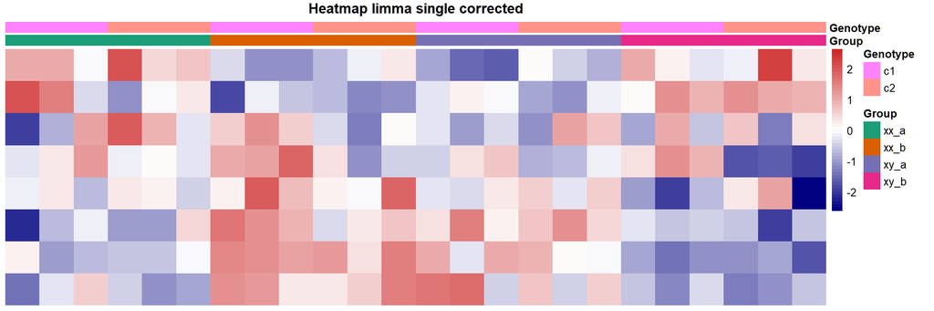

```r
# and limma
heatmap_limma_single <- create_heatmap(vsd_limma_filtered, "Heatmap limma single corrected")
```

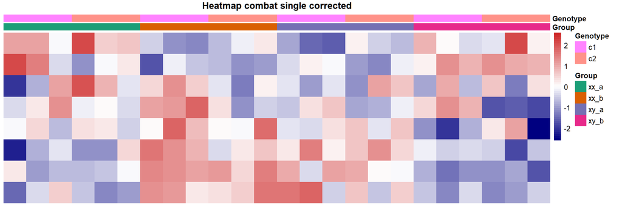

```r
# and combat
heatmap_combat_single <- create_heatmap(vsd_combat_single_filtered, "Heatmap combat single corrected")
```

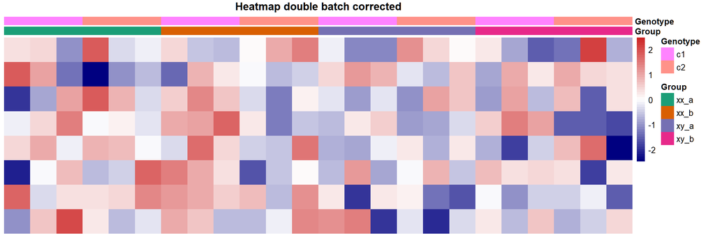

```r
# double corrected
heatmap_double <- create_heatmap(vsd_double_filtered, "Heatmap double batch corrected")
```

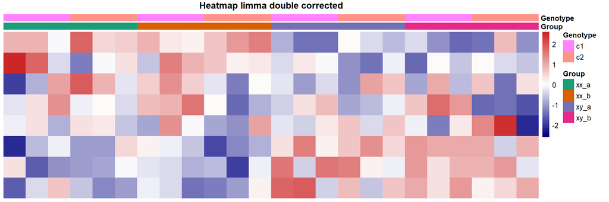

```r
# and limma
heatmap_limma_double <- create_heatmap(vsd_limma_abc_filtered, "Heatmap limma double corrected")
```

[figure not shown]

```r
# and combat
heatmap_combat_double <- create_heatmap(vsd_combat_double_filtered, "Heatmap combat double corrected")

# show the uncorrected heatmap first
heatmap
```

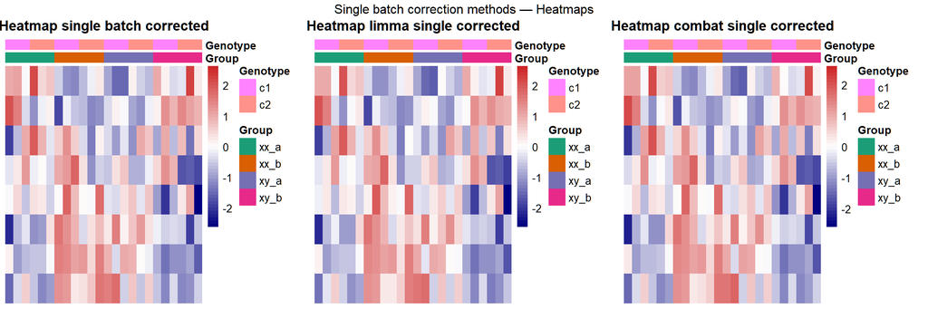

```r
# Extract the grob element if using pheatmap
g_single  <- heatmap_single$gtable
g_limma_s <- heatmap_limma_single$gtable
g_combat_s<- heatmap_combat_single$gtable

grid.arrange(g_single, g_limma_s, g_combat_s,
             ncol = 3,
             top = "Single batch correction methods — Heatmaps")
```